## Accesing the dataset from Data folder

```python
# importing necessary libraries
import pandas as pd
import matplotlib.pyplot as plt
import seaborn as sns
from sklearn.preprocessing import LabelEncoder
import warnings
warnings.filterwarnings('ignore')
```

# 1.Load and explore dataset

```python
df = pd.read_csv('Data/Churn_Modelling.csv')
df.head()
```

|  | RowNumber | CustomerId | Surname | CreditScore | Geography | Gender | Age | Tenure | Balance | NumOfProducts | HasCrCard | IsActiveMember | EstimatedSalary | Exited |
| --- | --- | --- | --- | --- | --- | --- | --- | --- | --- | --- | --- | --- | --- | --- |
| 0 | 1 | 15634602 | Hargrave | 619 | France | Female | 42.0 | 2 | 0.00 | 1 | 1.0 | 1.0 | 101348.88 | 1 |
| 1 | 2 | 15647311 | Hill | 608 | Spain | Female | 41.0 | 1 | 83807.86 | 1 | 0.0 | 1.0 | 112542.58 | 0 |
| 2 | 3 | 15619304 | Onio | 502 | France | Female | 42.0 | 8 | 159660.80 | 3 | 1.0 | 0.0 | 113931.57 | 1 |
| 3 | 4 | 15701354 | Boni | 699 | France | Female | 39.0 | 1 | 0.00 | 2 | 0.0 | 0.0 | 93826.63 | 0 |
| 4 | 5 | 15737888 | Mitchell | 850 | Spain | Female | 43.0 | 2 | 125510.82 | 1 | NaN | 1.0 | 79084.10 | 0 |

```python
df.shape
```

```
(10002, 14)
```

```python
df.info()
```

```
<class 'pandas.core.frame.DataFrame'>
RangeIndex: 10002 entries, 0 to 10001
Data columns (total 14 columns):
 #   Column           Non-Null Count  Dtype
---  ------           --------------  -----
 0   RowNumber        10002 non-null  int64
 1   CustomerId       10002 non-null  int64
 2   Surname          10002 non-null  object
 3   CreditScore      10002 non-null  int64
 4   Geography        10001 non-null  object
 5   Gender           10002 non-null  object
 6   Age              10001 non-null  float64
 7   Tenure           10002 non-null  int64
 8   Balance          10002 non-null  float64
 9   NumOfProducts    10002 non-null  int64
 10  HasCrCard        10001 non-null  float64
 11  IsActiveMember   10001 non-null  float64
 12  EstimatedSalary  10002 non-null  float64
 13  Exited           10002 non-null  int64
dtypes: float64(5), int64(6), object(3)
memory usage: 1.1+ MB
```

```python
df.describe()
```

|  | RowNumber | CustomerId | CreditScore | Age | Tenure | Balance | NumOfProducts | HasCrCard | IsActiveMember | EstimatedSalary | Exited |
| --- | --- | --- | --- | --- | --- | --- | --- | --- | --- | --- | --- |
| count | 10002.000000 | 1.000200e+04 | 10002.000000 | 10001.000000 | 10002.000000 | 10002.000000 | 10002.000000 | 10001.000000 | 10001.000000 | 10002.000000 | 10002.000000 |
| mean | 5001.499600 | 1.569093e+07 | 650.555089 | 38.922311 | 5.012498 | 76491.112875 | 1.530194 | 0.705529 | 0.514949 | 100083.331145 | 0.203759 |
| std | 2887.472338 | 7.193177e+04 | 96.661615 | 10.487200 | 2.891973 | 62393.474144 | 0.581639 | 0.455827 | 0.499801 | 57508.117802 | 0.402812 |
| min | 1.000000 | 1.556570e+07 | 350.000000 | 18.000000 | 0.000000 | 0.000000 | 1.000000 | 0.000000 | 0.000000 | 11.580000 | 0.000000 |
| 25% | 2501.250000 | 1.562852e+07 | 584.000000 | 32.000000 | 3.000000 | 0.000000 | 1.000000 | 0.000000 | 0.000000 | 50983.750000 | 0.000000 |
| 50% | 5001.500000 | 1.569073e+07 | 652.000000 | 37.000000 | 5.000000 | 97198.540000 | 1.000000 | 1.000000 | 1.000000 | 100185.240000 | 0.000000 |
| 75% | 7501.750000 | 1.575323e+07 | 718.000000 | 44.000000 | 7.000000 | 127647.840000 | 2.000000 | 1.000000 | 1.000000 | 149383.652500 | 0.000000 |
| max | 10000.000000 | 1.581569e+07 | 850.000000 | 92.000000 | 10.000000 | 250898.090000 | 4.000000 | 1.000000 | 1.000000 | 199992.480000 | 1.000000 |

```python
df.isnull().sum()
```

```
RowNumber          0
CustomerId         0
Surname            0
CreditScore        0
Geography          1
Gender             0
Age                1
Tenure             0
Balance            0
NumOfProducts      0
HasCrCard          1
IsActiveMember     1
EstimatedSalary    0
Exited             0
dtype: int64
```

```python
df.duplicated().sum()
```

```
2
```

```python
df['Exited'].value_counts()
```

```
Exited
0    7964
1    2038
Name: count, dtype: int64
```

```python
df['Exited'].value_counts(normalize=True)*100
```

```
Exited
0    79.624075
1    20.375925
Name: proportion, dtype: float64
```

As observed, our dataset comprises two classes with a distribution ratio of 79,6% to 20,4%, indicating a significant class imbalance. To address this issue, techniques such as oversampling the minority class or undersampling the majority class will be applied to balance the dataset in subsequent steps. However, prior to implementing any balancing methods, we will focus on data cleaning. This involves handling missing values, identifying and removing duplicates, and addressing potential outliers to ensure the dataset is consistent and suitable for modeling.

# 2. Data Cleaning

```python
# As first step, drop irrelevant columns: RowNumber, CustomerId, Surname
df = df.drop(['RowNumber', 'CustomerId', 'Surname'], axis=1)
print(df.columns)
```

```
Index(['CreditScore', 'Geography', 'Gender', 'Age', 'Tenure', 'Balance',
       'NumOfProducts', 'HasCrCard', 'IsActiveMember', 'EstimatedSalary',
       'Exited'],
      dtype='object')
```

```python
# Filters rows with any missing values
df[df.isnull().any(axis=1)]
```

|  | CreditScore | Geography | Gender | Age | Tenure | Balance | NumOfProducts | HasCrCard | IsActiveMember | EstimatedSalary | Exited |
| --- | --- | --- | --- | --- | --- | --- | --- | --- | --- | --- | --- |
| 4 | 850 | Spain | Female | 43.0 | 2 | 125510.82 | 1 | NaN | 1.0 | 79084.10 | 0 |
| 6 | 822 | NaN | Male | 50.0 | 7 | 0.00 | 2 | 1.0 | 1.0 | 10062.80 | 0 |
| 8 | 501 | France | Male | 44.0 | 4 | 142051.07 | 2 | 0.0 | NaN | 74940.50 | 0 |
| 9 | 684 | France | Male | NaN | 2 | 134603.88 | 1 | 1.0 | 1.0 | 71725.73 | 0 |

Considering the dataset contains 10,002 rows and specific NaN values in the filtered subset, it is acceptable to:

1. Delete rows with NaN values in the `Age` and `HasCrCard` columns.
2. Replace NaN values in the `Geography` column with most frequent value.
3. Set NaN values in the `IsActiveMember` column to `1.0` becouse this client have `Balance` greater than 0 and `Exited` = "0".

```python
# Step 1: Drop rows with NaN in 'Age' and 'HasCrCard'
df_cleaned = df.dropna(subset=['Age', 'HasCrCard'])

# Step 2: Fill missing values in 'Geography' using the mode
geography_mode = df_cleaned['Geography'].mode()[0]  # Use mode from 'df_cleaned'
df_cleaned['Geography'] = df_cleaned['Geography'].fillna(geography_mode)

# Step 3: Replace NaN in 'IsActiveMember' with '1.0'
df_cleaned['IsActiveMember'] = df_cleaned['IsActiveMember'].fillna("1.0")

# Step 4: Verify that all missing values have been handled
print("Check for Missing Values after cleaning:\n", df_cleaned.isnull().sum())
```

```
Check for Missing Values after cleaning:
 CreditScore        0
Geography          0
Gender             0
Age                0
Tenure             0
Balance            0
NumOfProducts      0
HasCrCard          0
IsActiveMember     0
EstimatedSalary    0
Exited             0
dtype: int64
```

```python
# Drop duplicates
df_cleaned = df_cleaned.drop_duplicates()
print("Check for Duplicates after cleaning:\n", df_cleaned.duplicated().sum())
```

```
Check for Duplicates after cleaning:
 0
```

```python
df_cleaned.head()
```

|  | CreditScore | Geography | Gender | Age | Tenure | Balance | NumOfProducts | HasCrCard | IsActiveMember | EstimatedSalary | Exited |
| --- | --- | --- | --- | --- | --- | --- | --- | --- | --- | --- | --- |
| 0 | 619 | France | Female | 42.0 | 2 | 0.00 | 1 | 1.0 | 1.0 | 101348.88 | 1 |
| 1 | 608 | Spain | Female | 41.0 | 1 | 83807.86 | 1 | 0.0 | 1.0 | 112542.58 | 0 |
| 2 | 502 | France | Female | 42.0 | 8 | 159660.80 | 3 | 1.0 | 0.0 | 113931.57 | 1 |
| 3 | 699 | France | Female | 39.0 | 1 | 0.00 | 2 | 0.0 | 0.0 | 93826.63 | 0 |
| 5 | 645 | Spain | Male | 44.0 | 8 | 113755.78 | 2 | 1.0 | 0.0 | 149756.71 | 1 |

```python
df_cleaned.shape
```

```
(9998, 11)
```

# 3. Exploratory Data Analysis (EDA)

For simplicity in code we will use `df_cleaned` as `df`.

```python
df = df_cleaned
```

## 3.1 Univariate Analysis

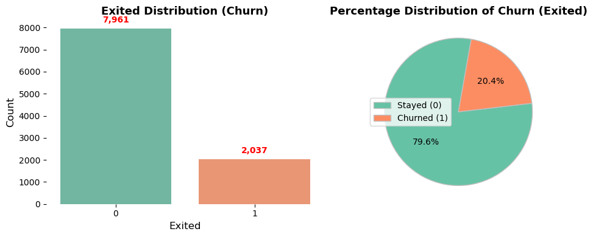

```python
# Count and percentage distribution of 'Exited'

exited_counts = df['Exited'].value_counts()
exited_percentage = df['Exited'].value_counts(normalize=True) * 100
fig, axes = plt.subplots(nrows=1, ncols=2, figsize=(10, 4))

# Subplot 1: Bar plot for Exited count distribution
sns.barplot(x=exited_counts.index, y=exited_counts, ax=axes[0], palette='Set2')
axes[0].set_title('Exited Distribution (Churn)', fontsize=13, fontweight='bold')
axes[0].set_xlabel('Exited', fontsize=12)
axes[0].set_ylabel('Count', fontsize=12)

# Annotate bars with exact counts
for bar in axes[0].patches:
    axes[0].annotate(f'{bar.get_height():,.0f}',  # Format count with thousands separator
                     (bar.get_x() + bar.get_width() / 2, bar.get_height()),
                     ha='center', va='center', xytext=(0, 10), textcoords='offset points',
                     fontsize=10, color='red', weight='bold')
# Remove unnecessary spines for cleaner visuals
sns.despine(left=True, bottom=True)

# Subplot 2: Pie chart for percentage distribution
axes[1].pie(exited_percentage,
            autopct='%1.1f%%',
            colors=sns.color_palette('Set2'),
            startangle=80,
            wedgeprops={'edgecolor': 'silver'})  # Add black edge for better visibility
axes[1].set_title('Percentage Distribution of Churn (Exited)', fontsize=13, fontweight='bold')

plt.legend(['Stayed (0)', 'Churned (1)'])
plt.tight_layout()  # Ensure plots do not overlap
plt.show()
```

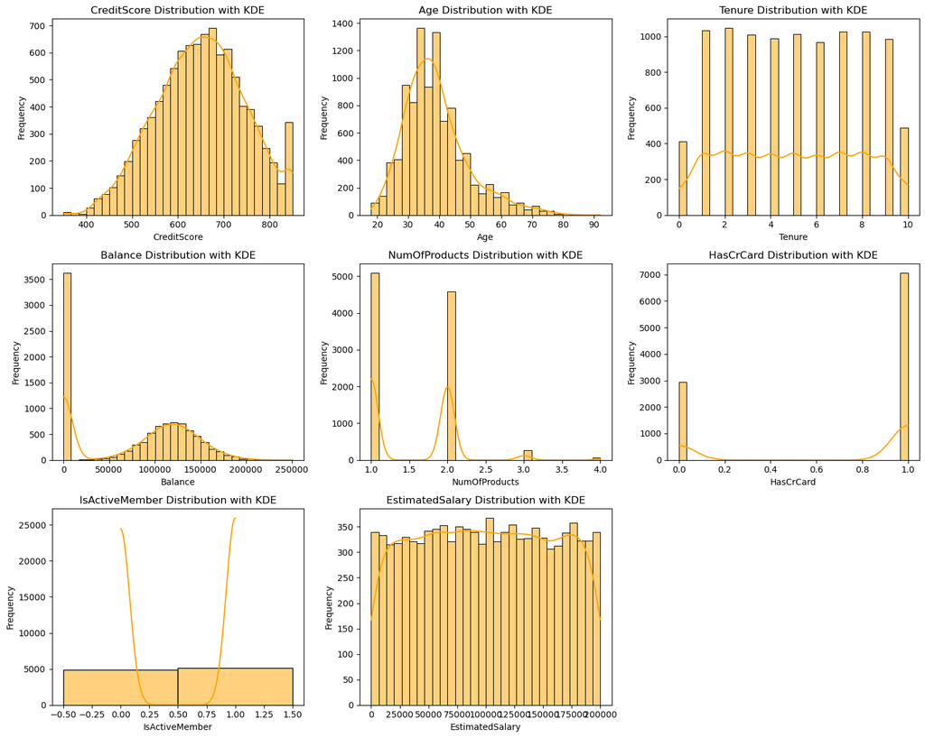

```python
# Function to perform univariate analysis for different numeric columns

def univariate_analysis(data, columns, grid_size=(3, 3), figsize=(15, 12)):
    fig, axes = plt.subplots(*grid_size, figsize=figsize)  # Create subplot grid
    axes = axes.flatten()  # Flatten axes for easy iteration

    for ax, column in zip(axes, columns):
        sns.histplot(data[column], kde=True, bins=30, color='orange' , ax=ax)
        ax.set_title(f'{column.replace("_", " ")} Distribution with KDE', fontsize=12)
        ax.set_xlabel(column.replace('_', ' '), fontsize=10)
        ax.set_ylabel('Frequency', fontsize=10)
    # Remove unused axes if columns < grid_size
    for ax in axes[len(columns):]:
        ax.axis('off')
    plt.tight_layout()
    plt.show()

# Columns to analyze
columns_to_analyze = ['CreditScore', 'Age', 'Tenure', 'Balance', 'NumOfProducts', 'HasCrCard', 'IsActiveMember', 'EstimatedSalary']

# Perform univariate analysis
univariate_analysis(df, columns_to_analyze)
```

## Feature Distributions with KDE

This chart visualizes the distributions of various features in the dataset using histograms with Kernel Density Estimates (KDE). Below is a description of each feature’s distribution:

### Features

1. **CreditScore**
   - Distribution: Approximately normal.
   - Observations: Most customers have a credit score between 500 and 800.
2. **Age**
   - Distribution: Right-skewed.
   - Observations: The majority of customers are between 30 and 50 years old.
3. **Tenure**
   - Distribution: Uniform.
   - Observations: Customers are evenly distributed across different tenure levels.
4. **Balance**
   - Distribution: Many customers have a balance of zero.
   - Observations: Balances range up to approximately 250,000, with a significant number clustered at zero.
5. **NumOfProducts**
   - Distribution: Peaks at 1 and 2 products.
   - Observations: Very few customers have 3 or 4 products.
6. **HasCrCard**
   - Distribution: Binary (0 or 1).
   - Observations: The majority of customers possess a credit card (`1`).
7. **IsActiveMember**
   - Distribution: Binary (0 or 1).
   - Observations: Slightly more customers are active members (`1`) than inactive ones.
8. **EstimatedSalary**
   - Distribution: Relatively uniform.
   - Observations: Salaries are spread evenly across the range, with a slight decrease at the higher end.

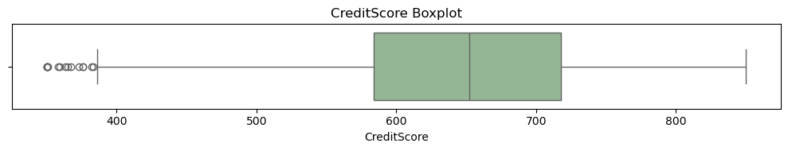

```
Summary Statistics for CreditScore:
 count    9998.000000
mean      650.505501
std        96.641794
min       350.000000
25%       584.000000
50%       652.000000
75%       717.750000
max       850.000000
Name: CreditScore, dtype: float64
```

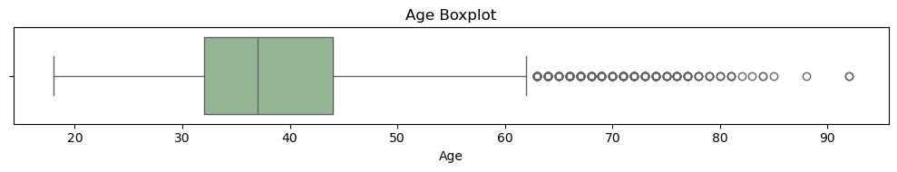

```
Summary Statistics for Age:
 count    9998.000000
mean       38.922688
std        10.488080
min        18.000000
25%        32.000000
50%        37.000000
75%        44.000000
max        92.000000
Name: Age, dtype: float64
```

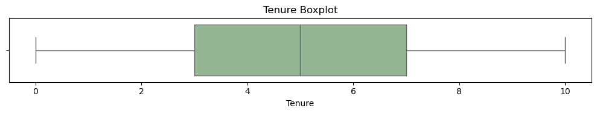

```
Summary Statistics for Tenure:
 count    9998.000000
mean        5.013403
std         2.892150
min         0.000000
25%         3.000000
50%         5.000000
75%         7.000000
max        10.000000
Name: Tenure, dtype: float64
```

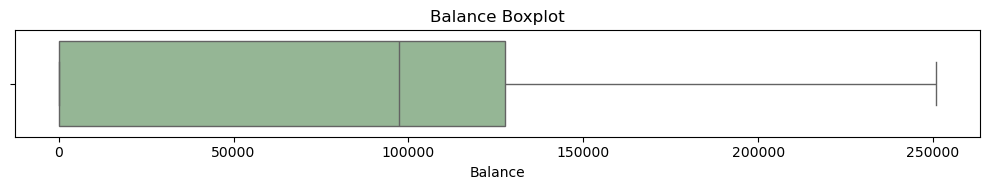

```
Summary Statistics for Balance:
 count      9998.000000
mean      76475.172853
std       62399.011964
min           0.000000
25%           0.000000
50%       97173.290000
75%      127641.417500
max      250898.090000
Name: Balance, dtype: float64
```

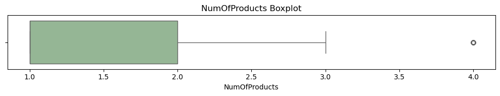

```
Summary Statistics for NumOfProducts:
 count    9998.000000
mean        1.530306
std         0.581664
min         1.000000
25%         1.000000
50%         1.000000
75%         2.000000
max         4.000000
Name: NumOfProducts, dtype: float64
```

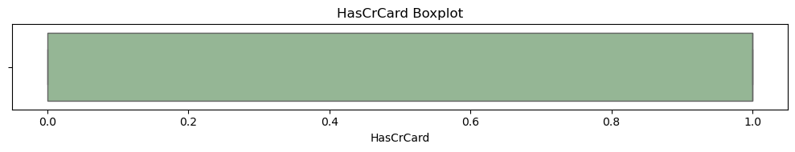

```
Summary Statistics for HasCrCard:
 count    9998.000000
mean        0.705441
std         0.455867
min         0.000000
25%         0.000000
50%         1.000000
75%         1.000000
max         1.000000
Name: HasCrCard, dtype: float64
```

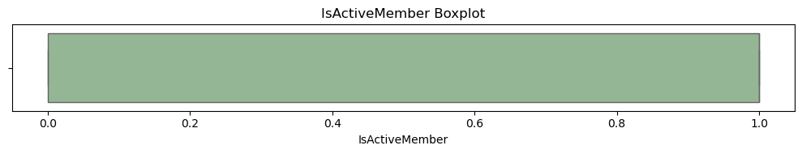

```
Summary Statistics for IsActiveMember:
 count     9998.0
unique       3.0
top          1.0
freq      5148.0
Name: IsActiveMember, dtype: float64
```

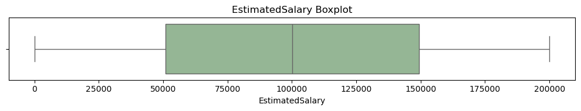

```
Summary Statistics for EstimatedSalary:
 count      9998.000000
mean     100095.177934
std       57515.161757
min          11.580000
25%       50983.750000
50%      100218.210000
75%      149395.882500
max      199992.480000
Name: EstimatedSalary, dtype: float64
```

```python
 # Function to perform univariate analysis for numeric columns
def univariate_analysis(data, column, title):
    plt.figure(figsize=(10, 2))

    sns.boxplot(x=data[column], color='darkseagreen')
    plt.title(f'{title} Boxplot')

    plt.tight_layout()
    plt.show()

    print(f'\nSummary Statistics for {title}:\n', data[column].describe())

columns_to_analyze = ['CreditScore', 'Age', 'Tenure', 'Balance', 'NumOfProducts', 'HasCrCard', 'IsActiveMember', 'EstimatedSalary']

for column in columns_to_analyze:
    univariate_analysis(df, column, column.replace('_', ' '))
```

```python
# Analyse categorical columns

def plot_categorical_distribution(column_name, data, palette='Set3'):
    unique_values = data[column_name].nunique()

    fig, axes = plt.subplots(1, 2, figsize=(10, 4))
    fig.suptitle(f"Analysis of '{column_name}'", fontsize=16, fontweight='bold')

    sns.countplot(y=column_name, data=data, palette=palette, ax=axes[0])
    axes[0].set_title(f"Count Distribution of {column_name}", fontsize=14)
    axes[0].set_xlabel('Count', fontsize=12)
    axes[0].set_ylabel(column_name, fontsize=12)

    for p in axes[0].patches:
        axes[0].annotate(f'{int(p.get_width())}',
                         (p.get_width(), p.get_y() + p.get_height() / 2),
                         ha='center', va='center',
                         xytext=(10, 0), textcoords='offset points',
                         fontsize=10, color='black', weight='bold')
    sns.despine(left=True, bottom=True)

    data[column_name].value_counts().plot.pie(
        autopct='%1.1f%%',
        colors=sns.color_palette(palette, unique_values),
        startangle=90,
        explode=[0.05] * unique_values,
        ax=axes[1],
        wedgeprops={'edgecolor': 'black', 'linewidth': 0.7}
    )
    axes[1].set_title(f"Percentage Distribution of {column_name}", fontsize=14)
    axes[1].set_ylabel('')

    plt.tight_layout(rect=[0, 0, 1, 0.95])  # Adjust layout to fit the suptitle
    plt.show()
```

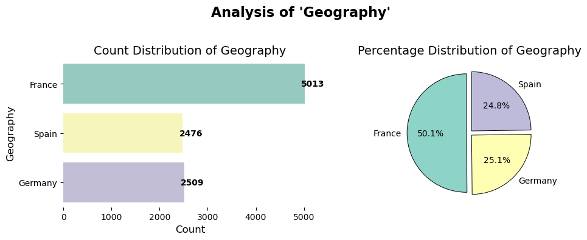

```python
plot_categorical_distribution(column_name='Geography', data=df)
```

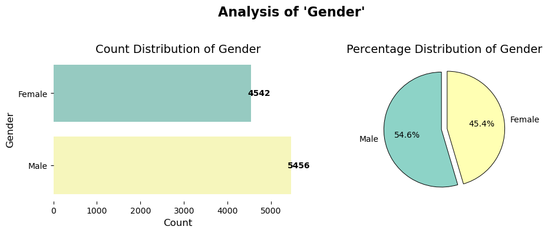

```python
plot_categorical_distribution(column_name='Gender', data=df)
```

## 3.2 Bivariate Analysis

```python
# Create a crosstab of Geography and Exited
contingency_table = pd.crosstab(df['Geography'], df['Exited'])

# Display the crosstab
print(contingency_table)
```

```
Exited        0    1
Geography
France     4203  810
Germany    1695  814
Spain      2063  413
```

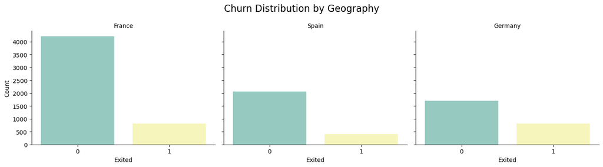

```python
# Create a FacetGrid to visualize Geography by Exited
g = sns.FacetGrid(df, col='Geography', height=4, aspect=1.2)

g.map(sns.countplot, 'Exited', palette='Set3')
g.set_titles("{col_name}")
g.set_axis_labels("Exited", "Count")
g.fig.suptitle('Churn Distribution by Geography', fontsize=16)
plt.tight_layout()
plt.show()
```

### Churn Distribution by Geography:

#### Observations:

France and Spain have relatively low churn rates, indicating better customer retention in these regions.

Germany appears to have a higher churn rate, suggesting that targeted strategies may be needed to address customer retention challenges in this region.

```python
# Create a crosstab of Gender and Exited
contingency_table = pd.crosstab(df['Gender'], df['Exited'])

# Display the crosstab
print(contingency_table)
```

```
Exited     0     1
Gender
Female  3403  1139
Male    4558   898
```

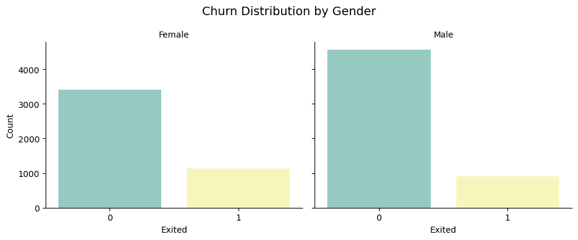

```python
# Create a FacetGrid to visualize Gender by Exited
g = sns.FacetGrid(df, col='Gender', height=4, aspect=1.2)

g.map(sns.countplot, 'Exited', palette='Set3')
g.set_titles("{col_name}")
g.set_axis_labels("Exited", "Count")
g.fig.suptitle('Churn Distribution by Gender', fontsize=14)
plt.tight_layout()
plt.show()
```

### Churn Distribution by Gender

#### Observations:

1. **Female Customers**: 25% churned (1,139 out of 4,542), while 75% did not churn.
2. **Male Customers**: 16% churned (898 out of 5,456), while 84% did not churn.

#### Insights:

- Female customers have a higher churn rate compared to male customers.
- Retention strategies should focus more on female customers to reduce churn.

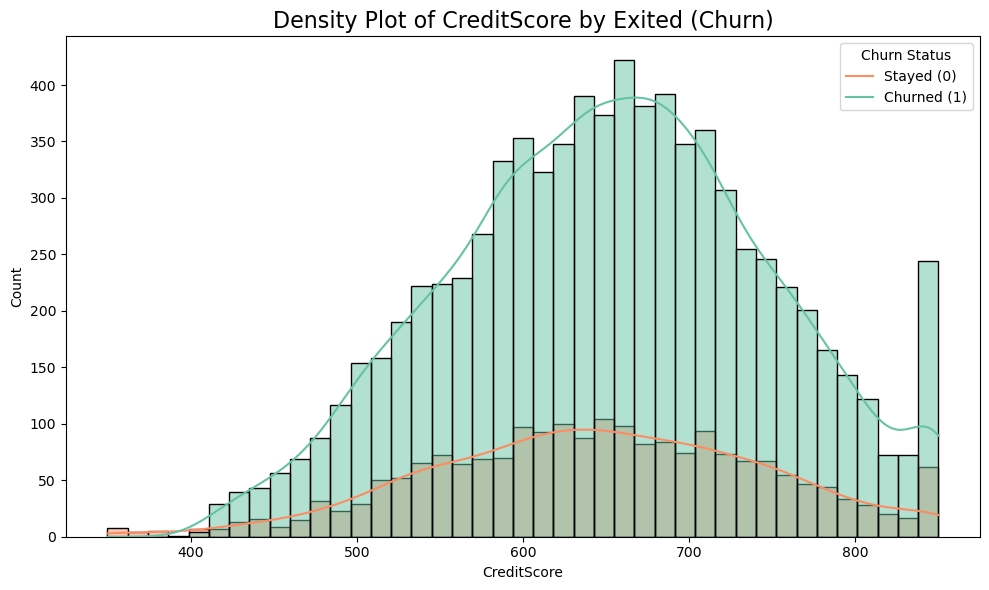

```python
# Create a histplot for CreditScore by Exited
plt.figure(figsize=(10, 6))
sns.histplot(data=df, x='CreditScore', hue='Exited', kde=True, fill=True, palette='Set2')
plt.title('Density Plot of CreditScore by Exited (Churn)', fontsize=16)
plt.xlabel('CreditScore')
plt.ylabel('Count')
plt.legend(title='Churn Status', labels=['Stayed (0)', 'Churned (1)'])
plt.tight_layout()
plt.show()
```

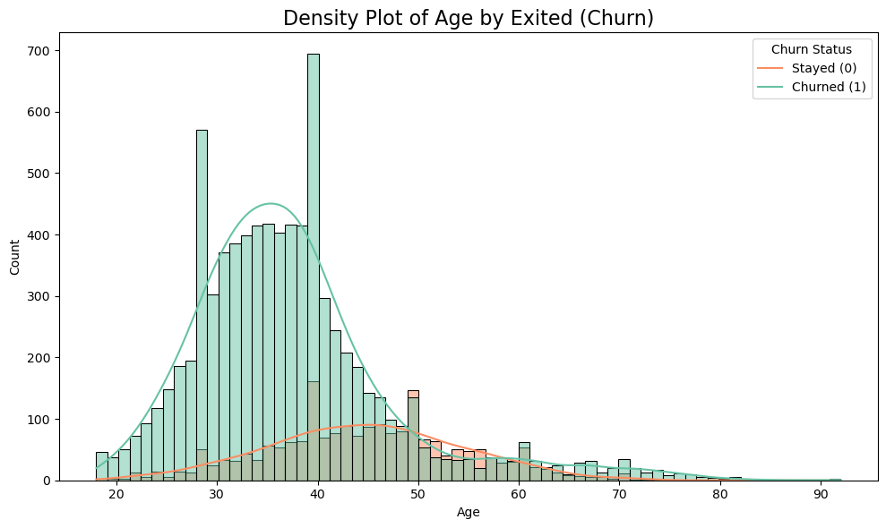

```python
# Plotting Age by Exited
plt.figure(figsize=(10, 6))
sns.histplot(data=df, x='Age', hue='Exited', kde=True, fill=True, palette='Set2')
plt.title('Density Plot of Age by Exited (Churn)', fontsize=16)
plt.xlabel('Age')
plt.ylabel('Count')
plt.legend(title='Churn Status', labels=['Stayed (0)', 'Churned (1)'])
plt.tight_layout()
plt.show()
```

### Density Plot of Age by Exited (Churn)

#### Summary:

This density plot visualizes the age distribution of customers, separated by churn status (`Exited`).

- **Churned Customers (Exited = 1)**:
  - Higher density in the age range of **40 to 60**, with a peak around the late 40s.
  - Suggests older customers are more likely to churn.
- **Non-Churned Customers (Exited = 0)**:
  - Distributed more evenly, with a peak around the **30s** and gradual decline thereafter.
  - Younger customers tend to stay longer.

#### Key Insight:

The likelihood of churn increases with age, especially for customers in the 40–60 age range. Retention strategies should focus on addressing the needs of this age group.

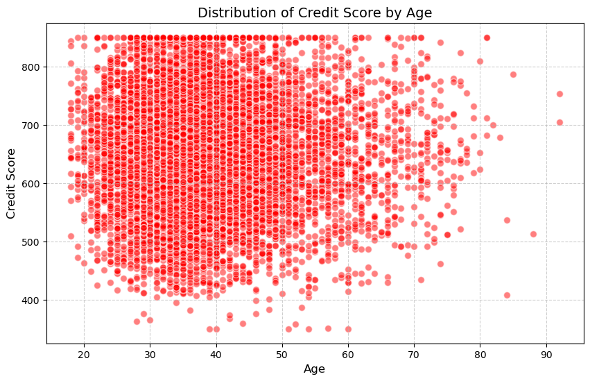

```python
# Plotting CreditScore by Age distribution
plt.figure(figsize=(10, 6))
plt.scatter(df['Age'], df['CreditScore'], alpha=0.5, c='red', edgecolors='w', s=50)
plt.title("Distribution of Credit Score by Age", fontsize=14)
plt.xlabel("Age", fontsize=12)
plt.ylabel("Credit Score", fontsize=12)
plt.grid(True, linestyle='--', alpha=0.6)
plt.show()
```

The distribution shows that credit scores are relatively independent of age, though the population skews younger.

Retention or credit improvement strategies may not require age-specific segmentation for credit scores.

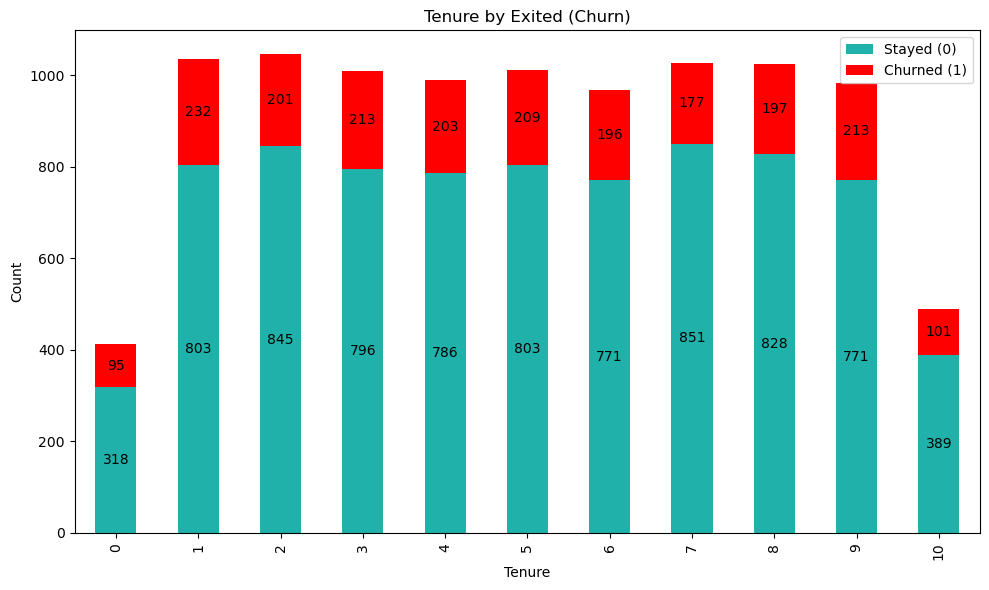

```python
# Group the data by Tenure and Exited to get counts
tenure_exited_counts = df.groupby(['Tenure', 'Exited']).size().unstack()
ax = tenure_exited_counts.plot(kind='bar', stacked=True, figsize=(10, 6), color=['lightseagreen', 'red'])

plt.title('Tenure by Exited (Churn)')
plt.xlabel('Tenure')
plt.ylabel('Count')
plt.legend(['Stayed (0)', 'Churned (1)'])
plt.tight_layout()

for p in ax.patches:
    width, height = p.get_width(), p.get_height()
    if height > 0:  # Avoid labels for zero heights
        x = p.get_x() + width / 2
        y = p.get_y() + height / 2
        ax.annotate(f'{int(height)}', (x, y), ha='center', va='center')

plt.show()
```

### Tenure by Exited (Churn)

#### Summary:

This stacked bar chart visualizes the churn (`Exited`) distribution across different tenure levels.

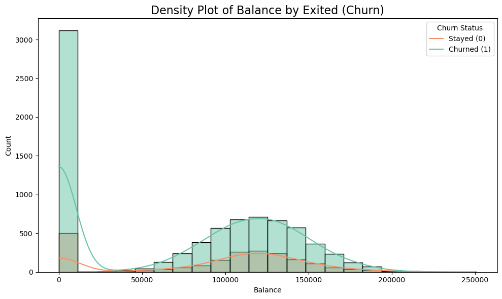

```python
# Create a histplot for Balance by Exited
plt.figure(figsize=(10, 6))
sns.histplot(data=df, x='Balance', hue='Exited', kde=True, fill=True, palette='Set2')
plt.title('Density Plot of Balance by Exited (Churn)', fontsize=16)
plt.xlabel('Balance')
plt.ylabel('Count')
plt.legend(title='Churn Status', labels=['Stayed (0)', 'Churned (1)'])
plt.tight_layout()
plt.show()
```

### Density Plot of Balance by Exited (Churn)

#### Summary:

This density plot illustrates the distribution of customer account balances, separated by churn status (`Exited`).

- **Key Observations**:
  1. **Zero Balance**:
     - A significant number of customers have a balance of **0**, with a higher proportion of non-churned customers (`Stayed = 0`).
  2. **Mid-Range Balances (50,000 - 150,000)**:
     - Both churned (`Exited = 1`) and non-churned customers are fairly distributed in this range.
  3. **High Balances (>150,000)**:
     - Few customers exist in this range, and they are more likely to remain (`Stayed = 0`).

#### Insights:

- Customers with zero balance are less likely to churn, suggesting that these may represent inactive accounts.
- Churn is more evenly distributed among customers with mid-range balances.
- Retention efforts might focus on mid-balance customers, where churn rates are more evenly distributed, to identify and address potential issues.

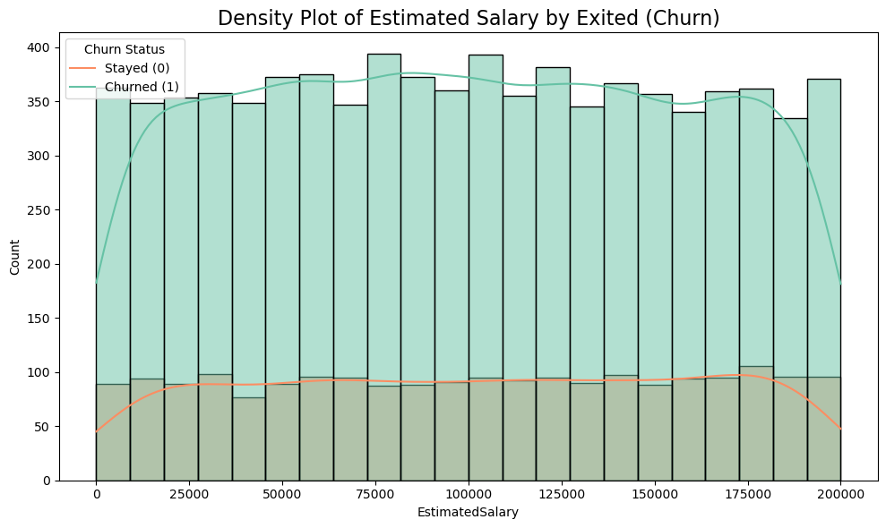

```python
# Create a histplot for EstimatedSalary by Exited
plt.figure(figsize=(10, 6))
sns.histplot(data=df, x='EstimatedSalary', hue='Exited', kde=True, fill=True, palette='Set2')
plt.title('Density Plot of Estimated Salary by Exited (Churn)', fontsize=16)
plt.xlabel('EstimatedSalary')
plt.ylabel('Count')
plt.legend(title='Churn Status', labels=['Stayed (0)', 'Churned (1)'])
plt.tight_layout()
plt.show()
```

### Density Plot of Estimated Salary by Exited (Churn)

#### Summary:

This density plot shows the distribution of estimated salaries among customers, separated by churn status (`Exited`).

- **Key Observations**:
  1. **Uniform Distribution**:
     - Salaries are evenly distributed across the range, with no significant peaks or valleys for either churned (`Exited = 1`) or non-churned customers (`Exited = 0`).
  2. **Churn Proportion**:
     - The churn proportion remains consistent across all salary levels, suggesting no strong correlation between estimated salary and churn behavior.

#### Insights:

- Salary appears to have little impact on customer churn, as the distribution is uniform and the churn rate does not vary significantly across the salary range.
- Retention strategies should focus on other factors influencing churn, as salary alone is not a differentiating variable.

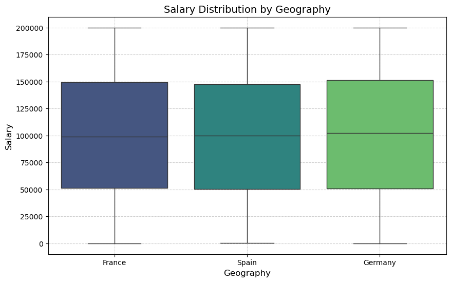

```python
# Plotting salary distribution by geography
plt.figure(figsize=(10, 6))
sns.boxplot(x="Geography", y="EstimatedSalary", data=df, palette="viridis")
plt.title("Salary Distribution by Geography", fontsize=14)
plt.xlabel("Geography", fontsize=12)
plt.ylabel("Salary", fontsize=12)
plt.grid(True, linestyle='--', alpha=0.6)
plt.show()
```

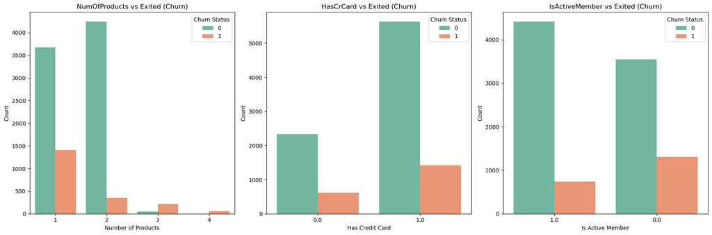

```python
plt.figure(figsize=(18, 6))

# Countplot for NumOfProducts vs Exited
plt.subplot(1, 3, 1)
sns.countplot(data=df, x='NumOfProducts', hue='Exited', palette='Set2')
plt.title('NumOfProducts vs Exited (Churn)')
plt.xlabel('Number of Products')
plt.ylabel('Count')
plt.legend(title='Churn Status')

# Countplot for HasCrCard vs Exited
plt.subplot(1, 3, 2)
sns.countplot(data=df, x='HasCrCard', hue='Exited', palette='Set2')
plt.title('HasCrCard vs Exited (Churn)')
plt.xlabel('Has Credit Card')
plt.ylabel('Count')
plt.legend(title='Churn Status')

# Countplot for IsActiveMember vs Exited
plt.subplot(1, 3, 3)
sns.countplot(data=df, x='IsActiveMember', hue='Exited', palette='Set2')
plt.title('IsActiveMember vs Exited (Churn)')
plt.xlabel('Is Active Member')
plt.ylabel('Count')
plt.legend(title='Churn Status')

plt.tight_layout()
plt.show()
```

### Categorical Feature Analysis by Exited (Churn)

#### 3. **IsActiveMember vs Exited (Churn)**

- Active members (`IsActiveMember = 1`) churn less frequently than inactive members.
- Churn is significantly higher among inactive members (`IsActiveMember = 0`), indicating strong retention challenges in this group.

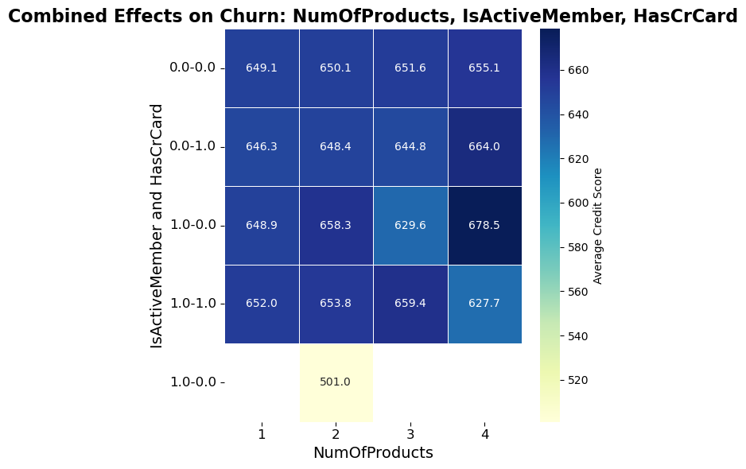

```python
# Visualizing the combined effects of NumOfProducts, IsActiveMember, and HasCrCard on Churn
plt.figure(figsize=(6, 6))

sns.heatmap(
    df.groupby(['NumOfProducts', 'IsActiveMember', 'HasCrCard'])['CreditScore']
    .mean()
    .unstack(level=0),
    annot=True,
    fmt=".1f",
    cmap="YlGnBu",
    linewidths=0.5,
    cbar_kws={'label': 'Average Credit Score'}  # Adds a descriptive color bar label
)

# Titles and Labels
plt.title("Combined Effects on Churn: NumOfProducts, IsActiveMember, HasCrCard", fontsize=16, fontweight='bold')
plt.xlabel("NumOfProducts", fontsize=14)
plt.ylabel("IsActiveMember and HasCrCard", fontsize=14)

# Adjusting tick labels for better readability
plt.xticks(fontsize=12)
plt.yticks(fontsize=12, rotation=0)

plt.tight_layout()  # Adjusts layout to prevent clipping
plt.show()
```

### Analysis of Combined Effects on Churn

# 3.3 Multivariate analysis

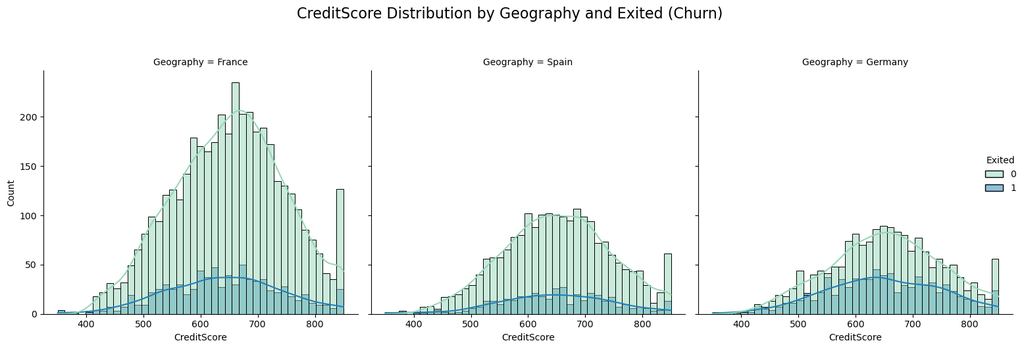

```python
# Plotting distribution of credit score by Geography and Exited
g = sns.displot(data=df, x="CreditScore", col="Geography", hue="Exited", kde=True, palette='YlGnBu')
g.fig.suptitle('CreditScore Distribution by Geography and Exited (Churn)', fontsize=16, y=1.05)
plt.tight_layout()
plt.show()
```

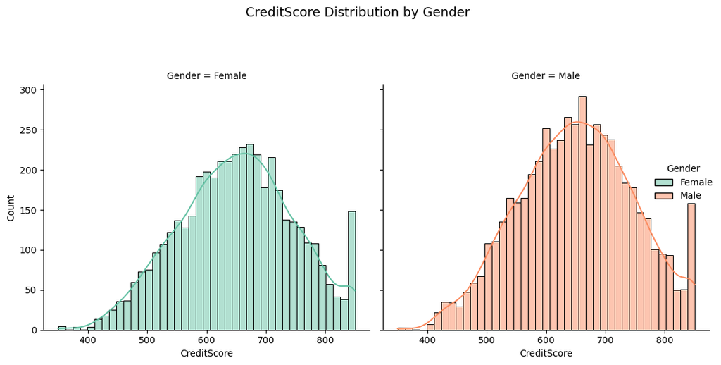

```python
# Create the displot
g = sns.displot(data=df, x="CreditScore", col="Gender", hue="Gender", kde=True, palette='Set2')
g.fig.suptitle('CreditScore Distribution by Gender', fontsize=14, y=1.10)
plt.tight_layout()
plt.show()
```

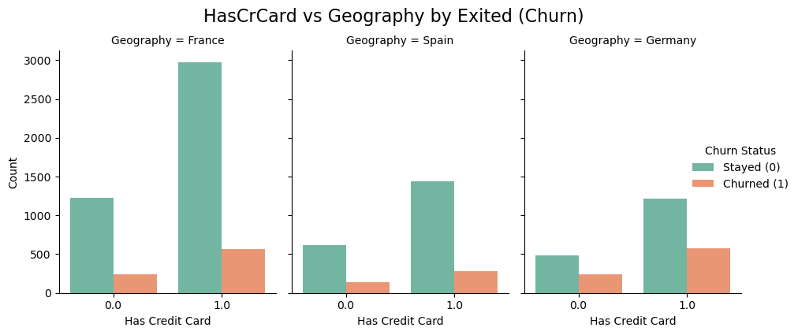

```python
# Create a catplot to visualize HasCrCard vs Geography by Exited
g = sns.catplot(
    data=df,
    x='HasCrCard',
    hue='Exited',
    col='Geography',
    kind='count',
    palette='Set2',
    height=4,
    aspect=0.8
)

g.fig.suptitle('HasCrCard vs Geography by Exited (Churn)', fontsize=16, y=1.05)
g.set_axis_labels('Has Credit Card', 'Count')
g._legend.set_title('Churn Status')
new_labels = ['Stayed (0)', 'Churned (1)']
for t, l in zip(g._legend.texts, new_labels): t.set_text(l)
plt.show()
```

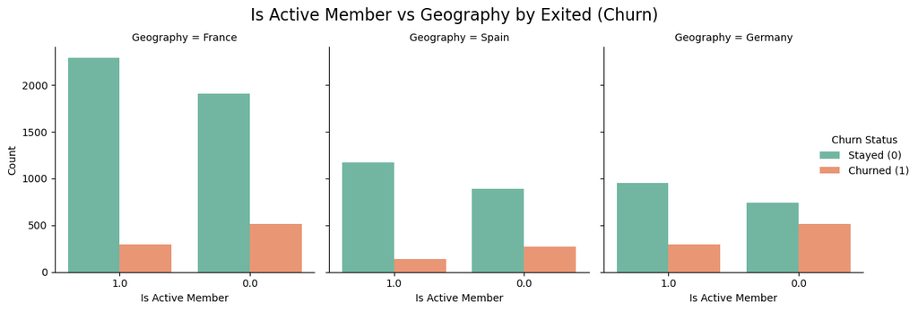

```python
# Create a catplot to visualize IsActiveMember vs Geography by Exited
g = sns.catplot(
    data=df,
    x='IsActiveMember',
    hue='Exited',
    col='Geography',
    kind='count',
    palette='Set2',
    height=4,
    aspect=1
)

g.fig.suptitle('Is Active Member vs Geography by Exited (Churn)', fontsize=16, y=1.05)
g.set_axis_labels('Is Active Member', 'Count')
g._legend.set_title('Churn Status')
new_labels = ['Stayed (0)', 'Churned (1)']
for t, l in zip(g._legend.texts, new_labels): t.set_text(l)
plt.show()
```

# 4. Data Preprocessing

Preparing accesible for modeling process

```python
# Initializing LabelEncoder
label_encoder = LabelEncoder()

# Encoding 'Geography'
df['Geography'] = label_encoder.fit_transform(df['Geography'])

# Encoding 'Gender'
df['Gender'] = label_encoder.fit_transform(df['Gender'])

print("Transformed Dataset:")
print(df.head())
```

```
Transformed Dataset:
   CreditScore  Geography  Gender   Age  Tenure    Balance  NumOfProducts  \
0          619          0       0  42.0       2       0.00              1
1          608          2       0  41.0       1   83807.86              1
2          502          0       0  42.0       8  159660.80              3
3          699          0       0  39.0       1       0.00              2
5          645          2       1  44.0       8  113755.78              2

   HasCrCard IsActiveMember  EstimatedSalary  Exited
0        1.0            1.0        101348.88       1
1        0.0            1.0        112542.58       0
2        1.0            0.0        113931.57       1
3        0.0            0.0         93826.63       0
5        1.0            0.0        149756.71       1
```

```python
# Save the  preprocessed DataFrame to a CSV file for further modeling process
df.to_csv('data/ModelingDataSet.csv', index=False)

print("DataFrame saved to 'data/ModelingDataSet.csv'")
```

```
DataFrame saved to 'data/ModelingDataSet.csv'
```

Now we are ready to start the modeling process.

For modeling we will use `ModelingDataSet.csv` in separate file.